# RUnning LDA

Author

Sarah Urbut

Published

August 4, 1021

## Quarto

In this document we will run the LDA model on the data generated in the previous step. We will use the `topicmodels` package to fit the LDA model, averaging our disease counts (max 1) for an individual over time. We will then visualize the results of the LDA model.

## Generate Data

We generate Data with 100 individuals, 5 diseases, 10 time points, and 3 topics (2 genetic features). I show the induced sparsity (max mu_d = 0.02 in this simulation)

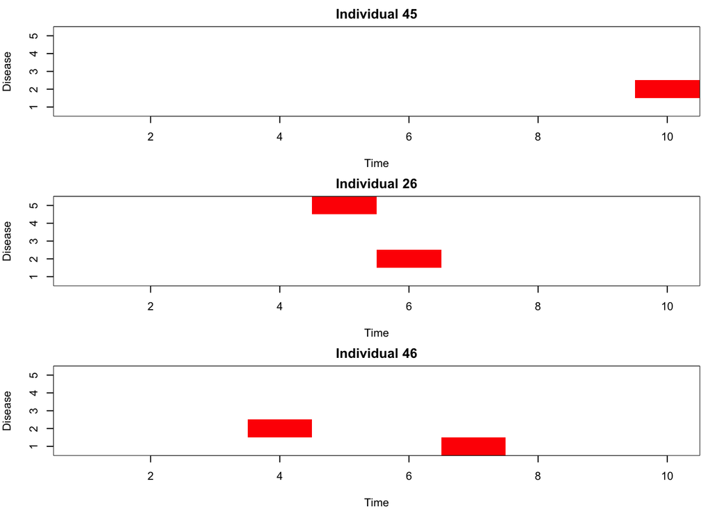

```r
library(topicmodels)
library(ggplot2)
source("../R/newsim.R")
# Assuming 'Y' is the array of N individuals, D diseases, and T time points from your data generation
data <- generate_tensor_data(N = 100, D = 5, T = 10, K = 3,num_covariates = 2)
plot_individuals(data$S,num_individuals = 3)
```

## Running LDA

1. Summing across the time dimension (3rd dimension) #### Collapse Y along the time dimension to get a matrix of individuals x diseases We will have to eliminate folks who have no disease (i.e. rowSums(Y_summed) == 0) We can then visualize the data to ensure that we have a count matrix, and plot our average $theta_ik$ and $eta_kd$ values. Recall that for a given topic our $eta_kd$ values need NOT sum to 1 across diseases.

```r
Y_summed <- apply(data$Y, c(1, 2), sum)
nullfolks=which(rowSums(Y_summed) == 0)
Y_summed=Y_summed[-nullfolks,]# Check and eliminate any individuals with no diseases

theta_summed <- apply(data$theta, c(1, 2), mean)
eta_summed <- apply(data$eta, c(1, 2), mean)
```

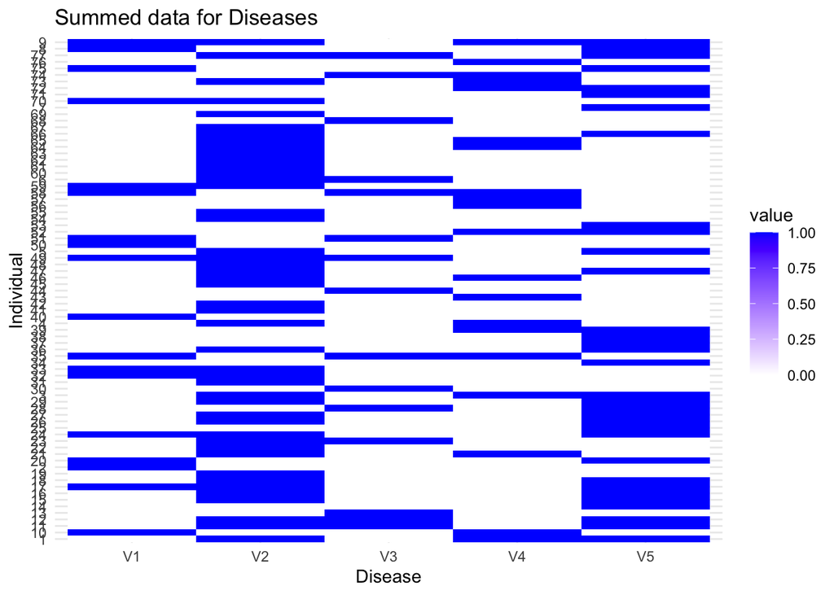

```r
# Assuming Y_summed is a matrix of diseases vs individuals
Y_df <- as.data.frame(Y_summed)
Y_df$Disease <- factor(rownames(Y_df))  # Adding Disease as a factor for y-axis

# Convert to long format for ggplot
Y_long <- reshape2::melt(Y_df, id.vars = "Disease")

# Plot with ggplot2
ggplot(Y_long, aes(x = variable, y = Disease, fill = value)) +
  geom_tile() +
  scale_fill_gradient(low = "white", high = "blue") +  # Adjust the color gradient
  labs(y = "Individual", x = "Disease", title = "Summed data for Diseases") +
  theme_minimal()
```

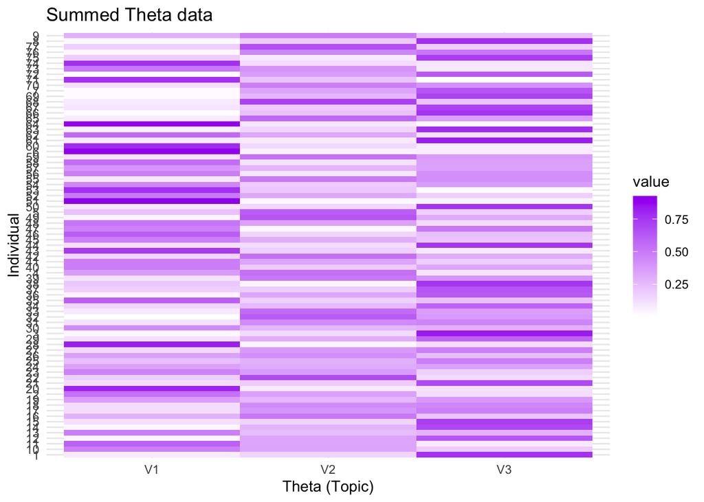

```r
# Assuming theta_summed[-nullfolks,] is a matrix with individuals and topics
theta_df <- as.data.frame(theta_summed[-nullfolks,])
theta_df$Theta <- factor(rownames(theta_df))  # Adding Theta (topics) as a factor for y-axis

# Convert to long format for ggplot
theta_long <- reshape2::melt(theta_df, id.vars = "Theta")

# Plot with ggplot2
ggplot(theta_long, aes(x = variable, y = Theta, fill = value)) +
  geom_tile() +
  scale_fill_gradient(low = "white", high = "purple") +  # Adjust the color gradient
  labs(y = "Individual", x = "Theta (Topic)", title = "Summed Theta data") +
  theme_minimal()
```

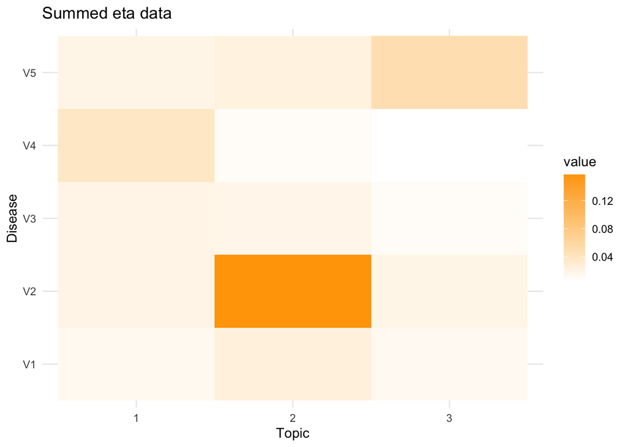

```r
# Assuming eta_summed is a matrix of topics and diseases
eta_df <- as.data.frame(eta_summed)
eta_df$Topic <- factor(rownames(eta_df))  # Adding Topic as a factor for x-axis

# Convert to long format for ggplot
eta_long <- reshape2::melt(eta_df, id.vars = "Topic")

# Plot with ggplot2
ggplot(eta_long, aes(x = Topic, y = variable, fill = value)) +
  geom_tile() +
  scale_fill_gradient(low = "white", high = "orange") +  # Adjust the color gradient
  labs(x = "Topic", y = "Disease", title = "Summed eta data") +
  theme_minimal()
```

Note that because this is NOT an allocation approach, eta need not sum to 1 across diseases for a topic (i.e. rowSums eta !=1)

## Run LDA

```r
# Ensure that the resulting matrix is a count matrix (LDA works with non-negative integers)
# Y_summed should now be a matrix where each row is an individual, and each column is a disease

# Run LDA using the topicmodels package
# Setting the number of topics (K)
K <- 3  # You can adjust the number of topics according to your needs

# Fitting the LDA model
lda_model <- LDA(Y_summed, k = K, method = "Gibbs")
```

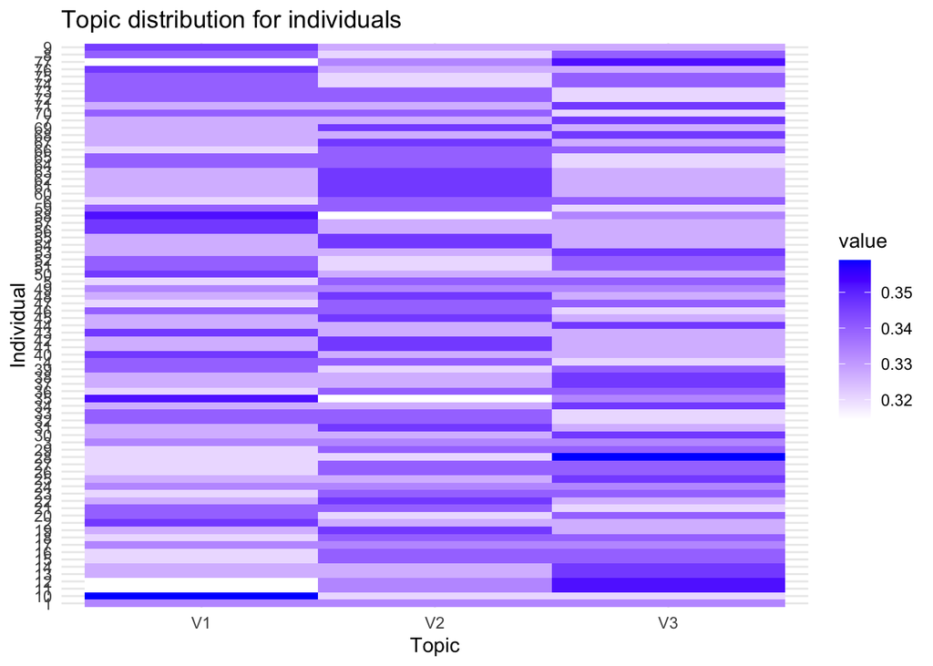

```r
# View the result
# Assuming lda_model@gamma is a matrix of topic proportions
library(ggplot2)
gamma_df <- as.data.frame(lda_model@gamma)
gamma_df$Topic <- factor(rownames(gamma_df))  # Adding Topic as a factor for y-axis

# Convert to long format for ggplot
gamma_long <- reshape2::melt(gamma_df, id.vars = "Topic")

# Plot with ggplot2
ggplot(gamma_long, aes(x = variable, y = Topic, fill = value)) +
  geom_tile() +
  scale_fill_gradient(low = "white", high = "blue") +  # Adjust the color gradient
  labs(y = "Individual", x = "Topic", title = "Topic distribution for individuals") +
  theme_minimal()
```

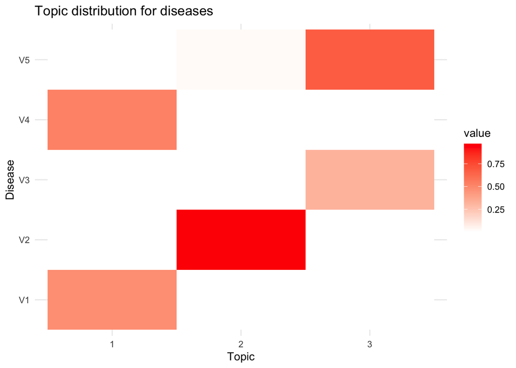

```r
# Assuming lda_model@beta is a matrix of disease probabilities per topic
beta_exp <- exp(lda_model@beta)  # If you're using exp to scale the values
beta_df <- as.data.frame(beta_exp)
beta_df$Topic <- factor(rownames(beta_df))  # Adding Topic as a factor for x-axis

# Convert to long format for ggplot
beta_long <- reshape2::melt(beta_df, id.vars = "Topic")

# Plot with ggplot2
ggplot(beta_long, aes(x = Topic, y = variable, fill = value)) +
  geom_tile() +
  scale_fill_gradient(low = "white", high = "red") +  # Adjust the color gradient
  labs(x = "Topic", y = "Disease", title = "Topic distribution for diseases") +
  theme_minimal()
```

The biggest problem here is that LDA fails to capture the variation in topic distribtuion (we have many folks with high topic variance) because by default it makes beta sum to 1.